# Problema 1 - Checkpoint 1 - Nossa Pergunta

# Existe, em cada uma das séries, um episódio que possui, a cada temporada, mais avaliações que os demais? Ex: toda temporada o ep 9 possui mais avaliações.

Para a primeira pergunta podemos observar os seguintes gráficos, que já foram mostrados no começo desse documento:

> > Quando optar por reutilizar um gráfico que já foi mostrado antes é melhor guardar ele em uma variável e chamar essa variável onde você deseja plotar; Evita código repetido.

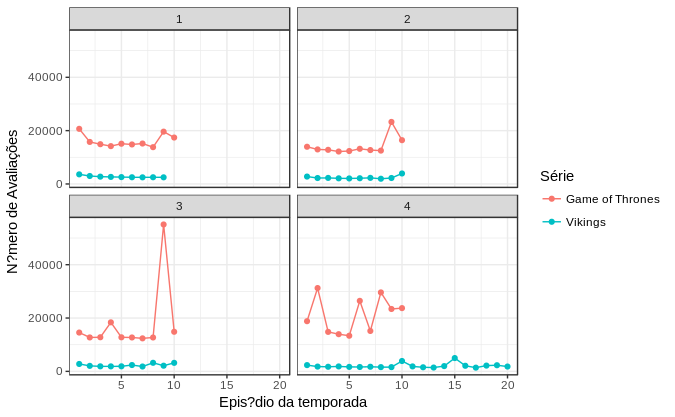

# Inícios e finais de temporadas são mais amados ou mais odiados?

Para a segunda pergunta, podemos observar os seguintes gráficos, já mostrados no começo do documento (segundo conjunto de gráficos):

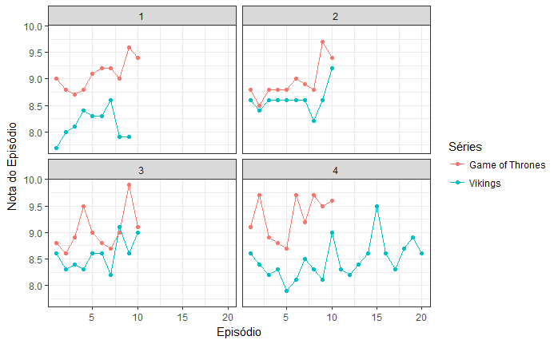